# Prediction Using COVID-19 Data from Johns Hopkins

Bill Kayser

# Introduction

This is an attempt to predict when recovery from the virus begins in different regions. I did a lot of exploration to see if there were any variables that I could normalize and model for prediction. I looked at many charts of Confirmed Cases and Deaths as well as their first and second derivatives.  
Data about Deaths is sparse, and the data about confirmed cases is unreliable.

Confirmed Cases is the total number of confirmed cases since the start of the outbreak. It does not take into account recoveries or deaths, and it never decreases. The time series chart of Confirmed Cases looks like the following.

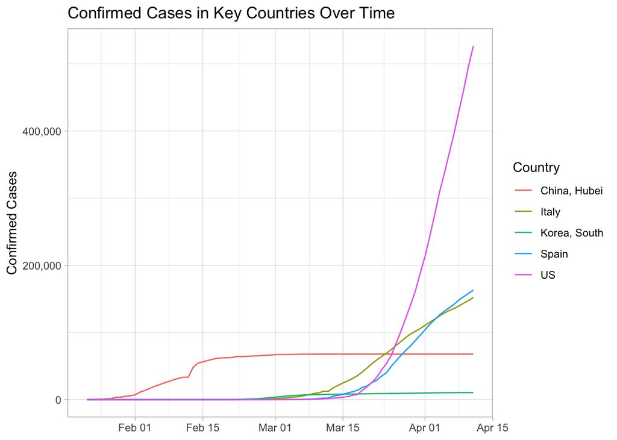

You can see this is increasing relentlessly in the US, Spain, and Italy. In China where Wuhan is and in South Korea the cases have leveld off. This seemed to beg the question…

**Can we predict when cases will level off in other regions?**

I kept digging through the data until the one thing that stuck out was the rate of growth of new cases. I derived this parameter from the of total Confirmed Cases shown in the plot above. I called it “Growth” and calculated it by taking the average number of new cases in the last three days and dividing it by the current total number of cases.

For example, if in Texas I had 300 new cases in the last three days, that would work out to an average of 100 cases per day. If the total number of cases is already 1000, then my growth rate is 10%. If the number of new cases holds steady until we get to 10,000 total cases in Texas, then the number of new cases–100 per day–is a growth rate of only 1%.

If the rate holds steady at 10%, then when we get to 10,000 cases in Texas, we’ll be seing about 1,000 new cases per day. This is the kind of growth we are generally seeing. But what I noticed is that the growth rate seems to have peaked just about everywhere and is on the decline. What we were calling exponential growth no longer seems exponential.

Here’s what that chart looks like.

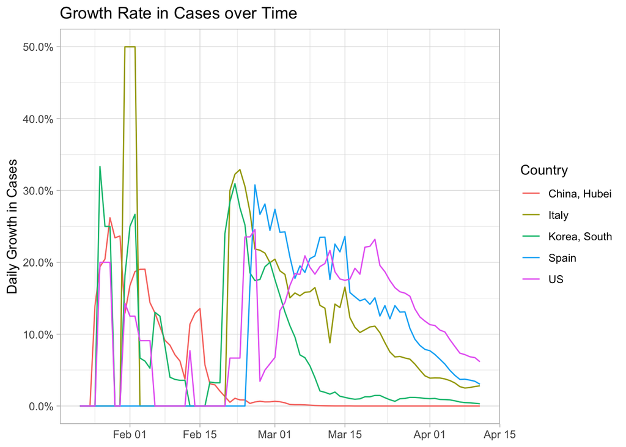

You can see this rate trending toward zero. In China and South Korea i’ts already pretty much leveled off at a point that represented a turnaround in both countries. It was late February in China and the second week of March for South Korea. The other countries seem to be on their way to zero.

# International Predictions

Then I used the linear model to predict on what date these countries will stop increasing new cases.

I believe these dates represent when things will be at their worst. There will be a relatively small number of new cases and the recoveries will have already kicked in, reducing the occupancy rates in hospitals.

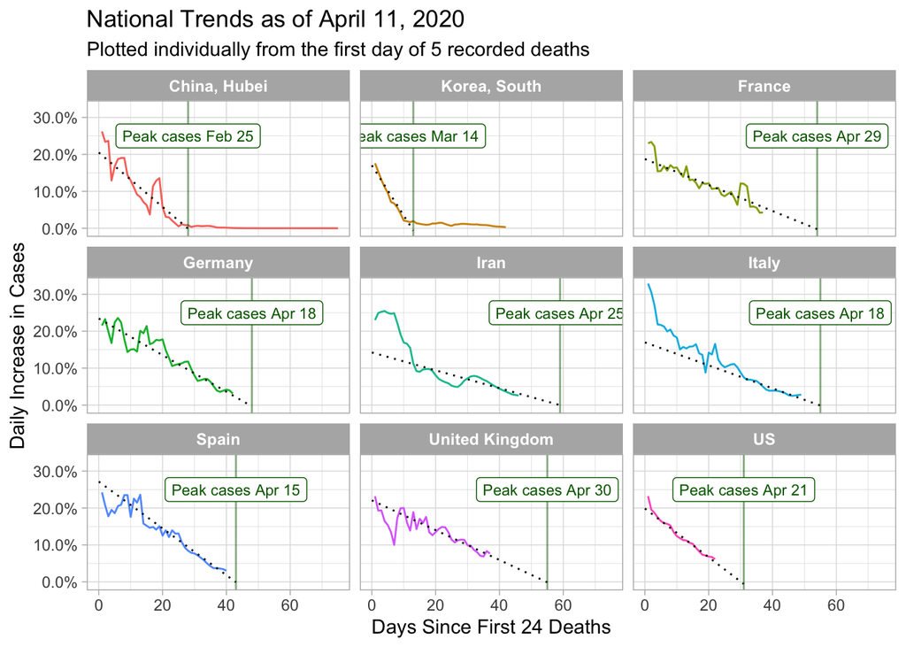

What’s key to note is that the prediction for China and South Korea is pretty much right on. The prediction line for other countries looks like a pretty good fit, and is particularly striking in France, Spain and the US.

# State by State Predictions

Then I turned to the US to see if I could go state by state.

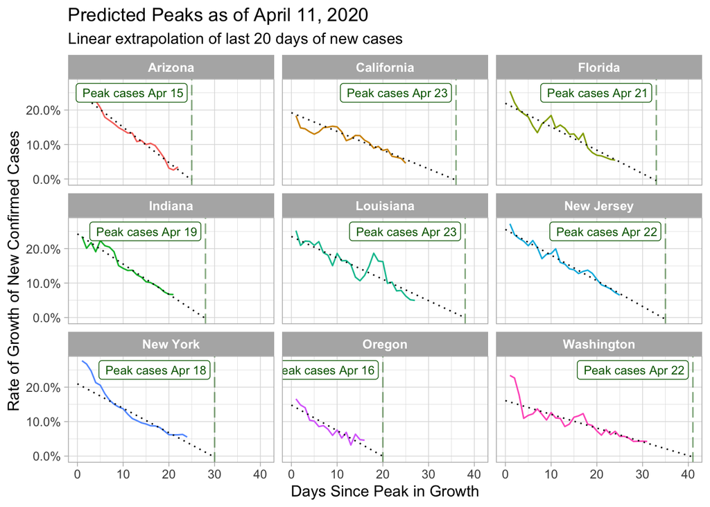

Finally, I ran a calculation on each state and put the results in a table.

| State | Date | Days.From.Now |
| --- | --- | --- |
| Alabama | 2020-04-24 | 13 days |
| Alaska | 2020-04-19 | 8 days |
| Arizona | 2020-04-15 | 4 days |
| Arkansas | 2020-04-14 | 3 days |
| California | 2020-04-23 | 12 days |
| Colorado | 2020-04-20 | 9 days |
| Connecticut | 2020-04-24 | 13 days |
| Delaware | 2020-05-10 | 29 days |
| District of Columbia | 2020-05-11 | 30 days |
| Florida | 2020-04-21 | 10 days |
| Georgia | 2020-04-27 | 16 days |
| Hawaii | 2020-04-16 | 5 days |
| Idaho | 2020-04-14 | 3 days |
| Illinois | 2020-04-23 | 12 days |
| Indiana | 2020-04-19 | 8 days |
| Iowa | 2020-04-26 | 15 days |
| Kansas | 2020-04-20 | 9 days |
| Kentucky | 2020-04-16 | 5 days |
| Louisiana | 2020-04-23 | 12 days |
| Maine | 2020-04-18 | 7 days |
| Maryland | 2020-05-09 | 28 days |
| Massachusetts | 2020-04-23 | 12 days |
| Michigan | 2020-04-18 | 7 days |
| Minnesota | 2020-04-21 | 10 days |
| Mississippi | 2020-04-19 | 8 days |
| Missouri | 2020-04-18 | 7 days |
| Montana | 2020-04-15 | 4 days |
| Nebraska | 2020-04-25 | 14 days |
| Nevada | 2020-04-25 | 14 days |
| New Hampshire | 2020-04-15 | 4 days |
| New Jersey | 2020-04-22 | 11 days |
| New Mexico | 2020-04-21 | 10 days |
| New York | 2020-04-18 | 7 days |
| North Carolina | 2020-04-22 | 11 days |
| North Dakota | 2020-04-21 | 10 days |
| Ohio | 2020-04-19 | 8 days |
| Oklahoma | 2020-04-17 | 6 days |
| Oregon | 2020-04-16 | 5 days |
| Pennsylvania | 2020-04-25 | 14 days |
| Rhode Island | 2020-05-06 | 25 days |
| South Carolina | 2020-04-23 | 12 days |
| South Dakota | 2022-03-16 | 704 days |
| Tennessee | 2020-04-19 | 8 days |
| Texas | 2020-04-29 | 18 days |
| Utah | 2020-04-18 | 7 days |
| Vermont | 2020-04-18 | 7 days |
| Virginia | 2020-05-02 | 21 days |
| Washington | 2020-04-22 | 11 days |
| West Virginia | 2020-04-26 | 15 days |
| Wisconsin | 2020-04-20 | 9 days |
| Wyoming | 2020-04-15 | 4 days |

# What’s Next?

If I am going to keep developing this I’ll probably try to mix in data on recoveries to see if I can predict the next milestone. If this predicted milestone is when things are at their worst, the next milestone is when we’ve recovered enough to where restrictions can be loosened.